# Multinomial Logistic Regression

Mariam Walaa

```r
library(nnet)
library(MASS)
library(palmerpenguins)
library(corrplot)
library(tidyverse)
```

## Data

This part uses the palmer penguins dataset provided by the Long Term Ecological Research Network and including measurements for penguins located in an island in Palmer Archipelago, such as flipper length, body mass, bill dimensions, and sex.

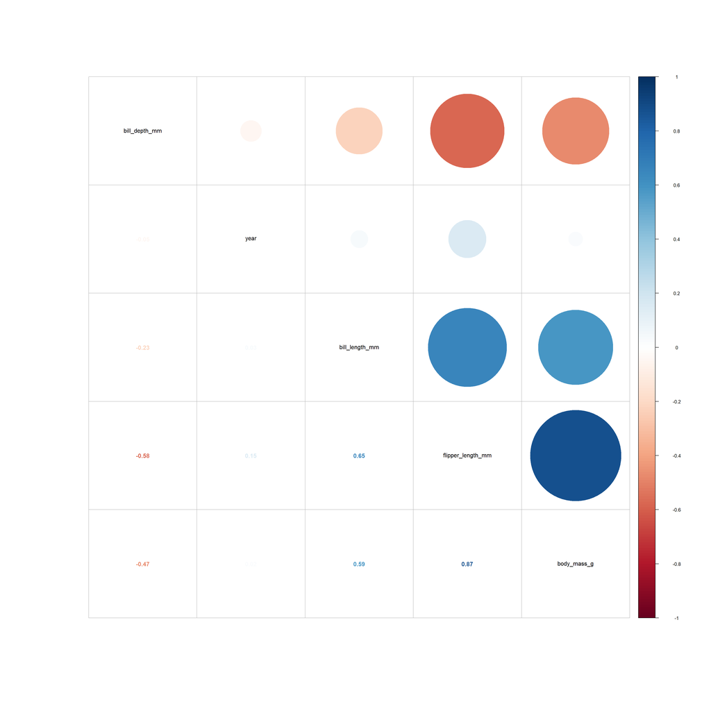

```r
penguins %>%
  na.omit() %>%
  select(!c("species", "island", "sex")) %>%
  cor() %>%
  corrplot.mixed(order = "hclust", tl.col = "black")
```

The flipper length, bill length, and body mass are strongly positively correlated while bill depth is negatively correlated to them all, and year of study is not correlated to anything.

```r
penguins$species <- relevel(penguins$species, ref = "Gentoo")
penguins <- penguins %>%
  na.omit()
```

```r
summary(stepAIC(multinom(species ~.,
                         data = penguins,
                         trace = FALSE),
                trace = FALSE))$anova
```

```
## Stepwise Model Path
## Analysis of Deviance Table
##
## Initial Model:
## species ~ island + bill_length_mm + bill_depth_mm + flipper_length_mm +
##     body_mass_g + sex + year
##
## Final Model:
## species ~ bill_length_mm + bill_depth_mm + body_mass_g
##
##
##                  Step Df     Deviance Resid. Df   Resid. Dev      AIC
## 1                                           315 6.127677e-04 36.00061
## 2            - island  4 0.0005703586       319 4.240917e-05 28.00004
## 3               - sex  2 0.0001458725       321 1.882817e-04 24.00019
## 4              - year  2 0.0018448096       323 2.033091e-03 20.00203
## 5 - flipper_length_mm  2 1.1633475769       325 1.165381e+00 17.16538
```

```r
model <- multinom(species ~
                    bill_length_mm +
                    bill_depth_mm +
                    sex,
                  data = penguins,
                  trace = FALSE)

summary(model)
```

```
## Call:
## multinom(formula = species ~ bill_length_mm + bill_depth_mm +
##     sex, data = penguins, trace = FALSE)
##
## Coefficients:
##           (Intercept) bill_length_mm bill_depth_mm   sexmale
## Adelie        68.3321    -20.9911162      48.23124  14.73724
## Chinstrap   -261.0223      0.0716487      16.37093 -27.62236
##
## Std. Errors:
##           (Intercept) bill_length_mm bill_depth_mm  sexmale
## Adelie       11.89323     15.7501532      38.84125 98.48215
## Chinstrap   224.39969      0.6274983      14.05645 27.56220
##
## Residual Deviance: 1.211962
## AIC: 17.21196
```

The multinomial regression summary provides coefficients for 2 of the 3 species, Adelie and Chinstrap. The effect on the dependent variable for the 3rd species can be computed by setting the independent variables to zero. Each coefficient of an independent variable can be used to determine the change in log-odds of being a certain type of species for a 1 unit change in that independent variable.

```r
(1 - pnorm(abs(summary(model)$coefficients /
                 summary(model)$standard.errors), 0, 1)) * 2
```

```
##            (Intercept) bill_length_mm bill_depth_mm   sexmale
## Adelie    9.166926e-09      0.1826118     0.2143277 0.8810457
## Chinstrap 2.447473e-01      0.9090939     0.2441582 0.3162553
```

```r
round(exp(coef(model)), 3)
```

```
##            (Intercept) bill_length_mm bill_depth_mm sexmale
## Adelie    4.745205e+29          0.000  8.842241e+20 2513622
## Chinstrap 0.000000e+00          1.074  1.287675e+07       0
```

```r
round(exp(confint(model)), 3)
```

```
## , , Adelie
##
##                       2.5 %       97.5 %
## (Intercept)    3.570447e+19 6.306485e+39
## bill_length_mm 0.000000e+00 1.950872e+04
## bill_depth_mm  0.000000e+00 1.019289e+54
## sexmale        0.000000e+00 1.692227e+90
##
## , , Chinstrap
##
##                2.5 %       97.5 %
## (Intercept)    0.000 4.454689e+77
## bill_length_mm 0.314 3.675000e+00
## bill_depth_mm  0.000 1.187627e+19
## sexmale        0.000 2.915730e+11
```

```r
predict(model,
        penguins[,2:8],
        type = "probs") %>%
  apply(1, which.max) -> predictions

table(penguins$species, predictions)
```

```
##            predictions
##               1   2   3
##   Gentoo    119   0   0
##   Adelie      0 146   0
##   Chinstrap   0   0  68
```

Each species is predicted with 100% accuracy.